# Creative Assignment 3

Maggie Weese

9/25/2020

# Loading Data

```r
library(sf)
library(tidyverse)
library(ggthemes)
library(rnaturalearth)
library(ggspatial)
library(cartogram)
library(rgdal)
library(units)
library(nngeo)
library(ggplot2)
library(RColorBrewer)
```

## Loading Data for Baltimore City

All the data retrieved was from https://data.baltimorecity.gov/browse?provenance=official&q=neighborhoods&sortBy=relevance&page=2. From the site, I loaded two polygon data sets, neighborhood and vegetated area, and three point data sets, Charm City circulator bus stops, schools and library locations.

## Modifying Coordinate System

I accessed my coordinate plan athttps://spatialreference.org/ and went with the SR-ORG:7898, Baltimore City’s coordinate system.

```r
Bmore_plane <-"+proj=omerc +lat_0=39.304635 +lonc=-76.614429 +alpha=0 +k=1 +x_0=106.4881889763779 +y_0=788.8544577089153 +ellps=GRS80 +datum=NAD83 +to_meter=0.3048006096012192 +no_defs"

neighborhoods <- neighborhoods  %>%
  st_transform(Bmore_plane)


libs <- libs  %>%
  st_transform(Bmore_plane)

busstop <- busstop %>%
  st_transform(Bmore_plane)

veggie <- veggie %>%
  st_transform(Bmore_plane)

schools <- schools %>%
  st_transform(Bmore_plane)
```

# Creating Geospatial Representations

## Initial Map of Variables

This is my initial attempt at creating a map of my variables: library locations, schools, bus stops, vegetated area, and neighborhoods.

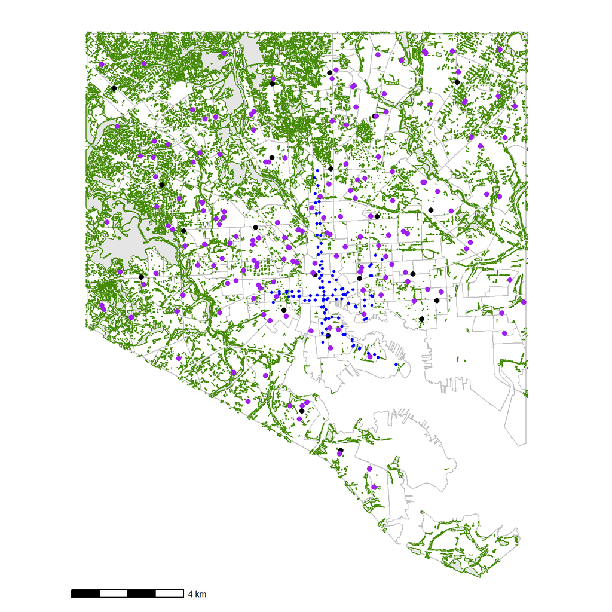

```r
ggplot(neighborhoods) +
  geom_sf(fill=NA, color="grey") +
  geom_sf(data=veggie, color="chartreuse4") +
  geom_sf(data=libs, color="black", size=2) +
  geom_sf(data=busstop, color="blue", size=1) +
  geom_sf(data=schools, color="purple", size=2) +
  annotation_scale() +
  theme_map()
```

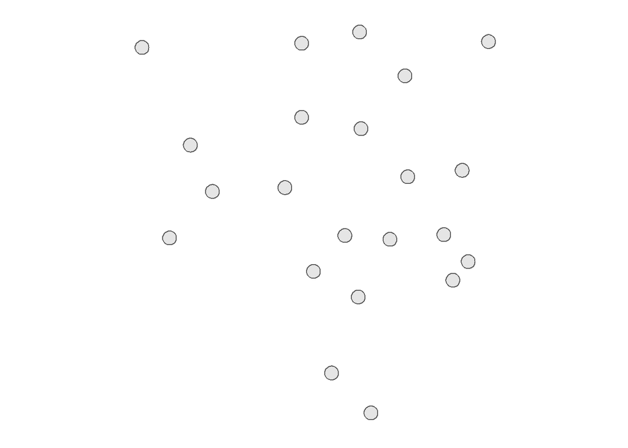

```r
libs_buffer <- st_buffer(libs, dist = 800) %>%
  st_union()

ggplot(libs_buffer) +
  geom_sf() +
  theme_map()
```

### Subsetting Data Points of Bus Stops with a Polygon of Libraries

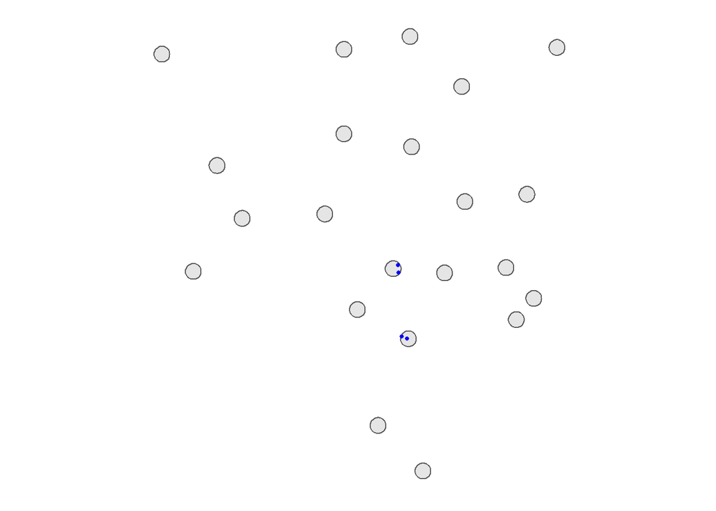

```r
busstop_libs <- busstop[libs_buffer,]

ggplot(libs_buffer) +
  geom_sf() +
  geom_sf(data = busstop_libs,
          color = "blue",
          size = 1) +
  theme_map()
```

```r
busstop <- busstop %>%
  st_join(busstop_libs) %>%
  mutate(by_libs = !is.na(Name.y))

n_busstop_libs <- sum(busstop$by_libs)

n_busstop_libs
```

```
## [1] 4
```

Here, I convert the total number to a percentage of total Charm City Circulator bus stops, 4% of bus stops. This code was adapted from the code Carole provided in the tutorial.

```r
n_busstop<- length(busstop$by_libs)

pct_busstop_libs <- n_busstop_libs / n_busstop

pct_busstop_libs
```

```
## [1] 0.03603604
```

### Creating the Final Map of Charm City Circulator Bus Stops within 0.5 Miles of a Public Library

This code was adapted from the code Carole provided in the tutorial.

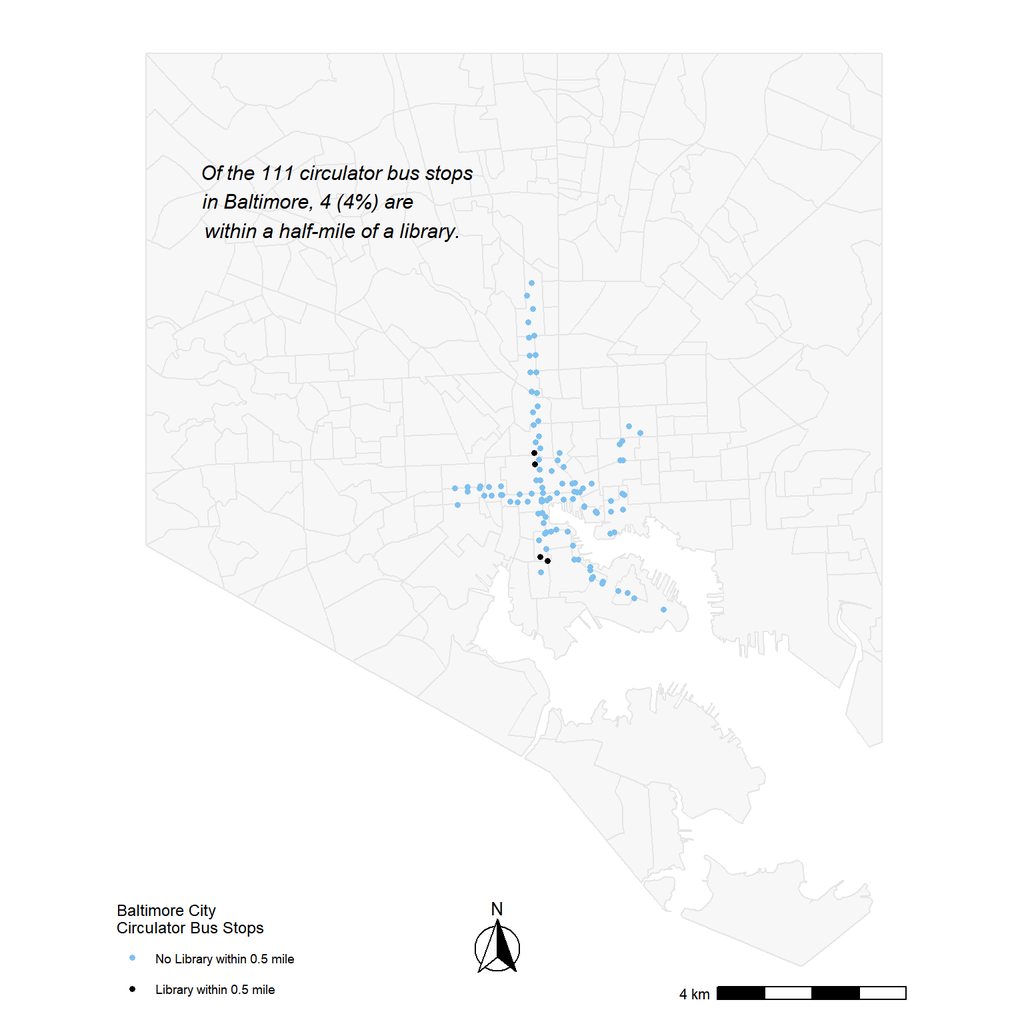

```r
#Need to figure out how to overlay the text over the graph

left_side  <- st_bbox(neighborhoods)$xmin
top_side <- st_bbox(neighborhoods)$ymax


ggplot(neighborhoods) +
  geom_sf(fill = "grey97", color = "grey90") +
  geom_sf(data = busstop, size = 1.2,
          aes(color = by_libs)) +
  scale_color_manual(values = c("skyblue2", "black"),
          name = "Baltimore City \nCirculator Bus Stops",
          labels = c("No Library within 0.5 mile",
                     "Library within 0.5 mile"))+
  annotation_scale(location = "br") +
  annotation_north_arrow(location = "tr", which_north = "true",
        pad_x = unit(3, "in"), pad_y = unit(7, "in"),
        style = north_arrow_fancy_orienteering) +
  annotate(geom = "text", x = left_side,
           y = top_side,
           label = paste(" Of the ",
                         prettyNum(n_busstop, big.mark = ","),
                         " circulator bus stops\n   in Baltimore, ",
                         prettyNum(n_busstop_libs, big.mark = ","),
                         " (",
                         prettyNum(100*pct_busstop_libs, digits = 0),
                         "%) are\n  within a half-mile of a library.",
                         sep = ""), fontface = "italic",
           hjust = -0.18, vjust = 2.5, size = 4) +
  theme_map()
```

## Chloropleth Map of Number of Schools in Baltimore Neighborhoods

Here, I look at the number of schools in each neighborhood in Baltimore and because we have so many neighborhoods in Baltimore, it looks a little wild with many neighborhoods having no schools at all. This map brings up questions around neighborhood boundaries and limitations to the information in this map. It looks as if there is no school in many of the neighborhoods, but given how small each neighborhoods is, each school likely pulls from multiple neighborhoods. In addition, the school could be just over a neighborhood line, still in close proximity, but not technically in the neighborhood. This code was adapted from the code Carole provided in the tutorial.

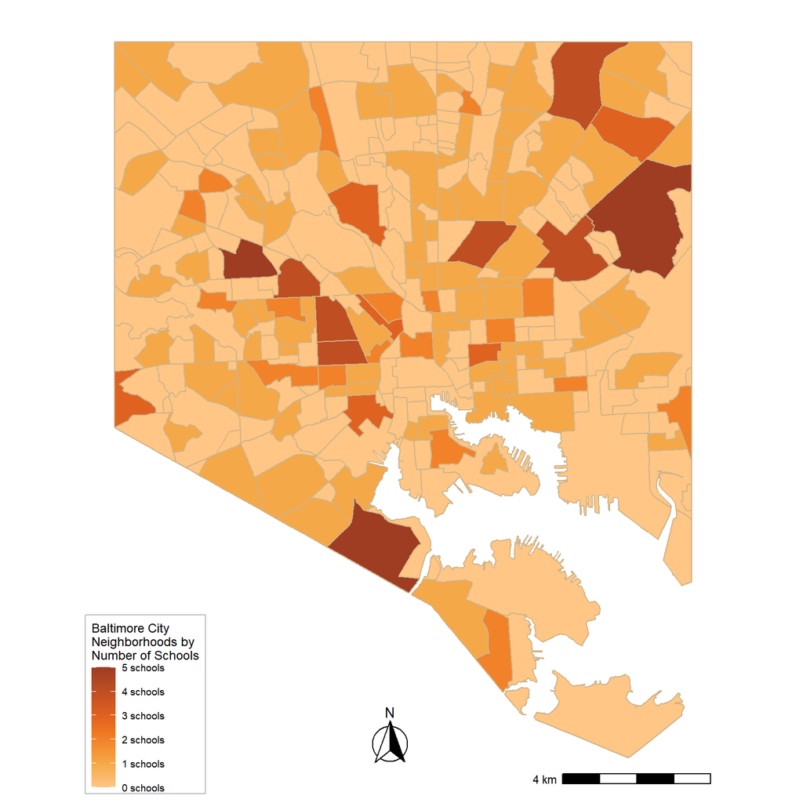

```r
neighborhoods <- neighborhoods %>%
  mutate(num_schools = lengths(st_covers(neighborhoods, schools)))


ggplot(neighborhoods) +
  geom_sf(color="navajowhite3",
          aes(fill=num_schools)) +
  scale_fill_continuous_tableau(palette = "Orange", name = "Baltimore City\nNeighborhoods by \nNumber of Schools",
                       breaks <- seq(0,10, by = 1),
                       labels = paste(prettyNum(breaks, big.mark = ","),
                                      "schools")) +
  annotation_scale(location="br") +
  annotation_north_arrow(location = "tr", which_north = "true",
        pad_x = unit(3, "in"), pad_y = unit(7, "in"),
        style = north_arrow_fancy_orienteering)  +
  theme_map() +
    theme(legend.background = element_rect(fill = alpha("white", 0.5),
                                            color="grey"))
```

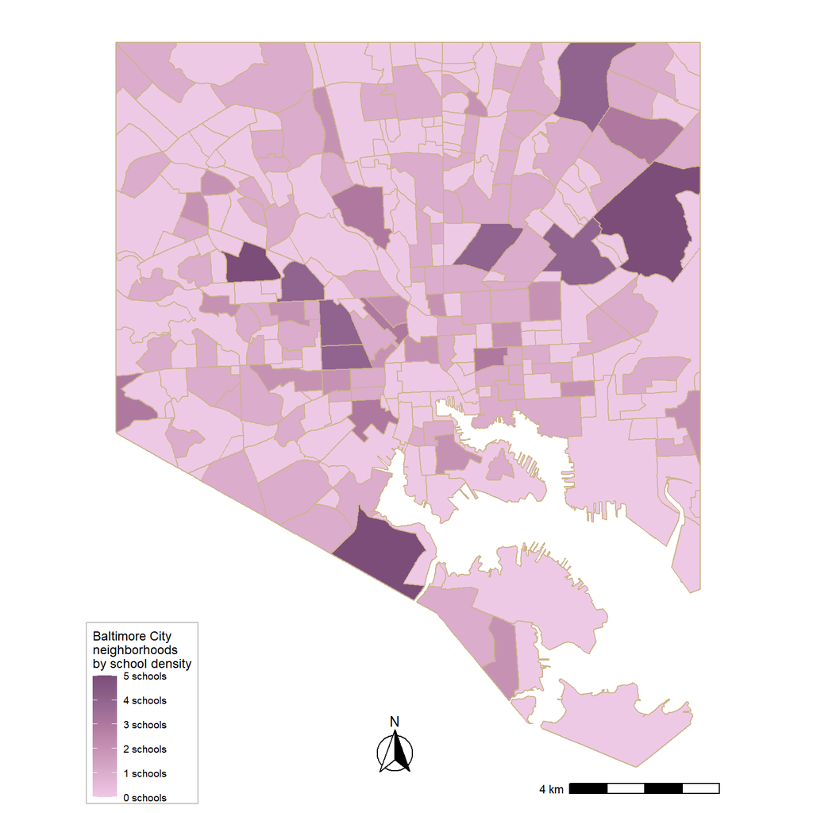

```r
neighborhoods <- neighborhoods %>%
  mutate(num_schools = lengths(st_covers(neighborhoods, schools)))


ggplot(neighborhoods) +
  geom_sf(color="navajowhite3",
          aes(fill=num_schools)) +
  scale_fill_continuous_tableau(palette = "Purple", name = "Baltimore City\nneighborhoods\nby school density",
                       breaks <- seq(0,10, by = 1),
                       labels = paste(prettyNum(breaks, big.mark = ","),
                                      "schools")) +
  annotation_scale(location="br") +
  annotation_north_arrow(location = "tr", which_north = "true",
        pad_x = unit(3, "in"), pad_y = unit(7, "in"),
        style = north_arrow_fancy_orienteering)  +
  theme_map() +
    theme(legend.background = element_rect(fill = alpha("white", 0.5),
                                            color="grey"))
```

## Map of Public Schools within 0.5 Miles of a Public Libraries

### Subsetting Data Points of Public Libraries with a Polygon of Public Schools

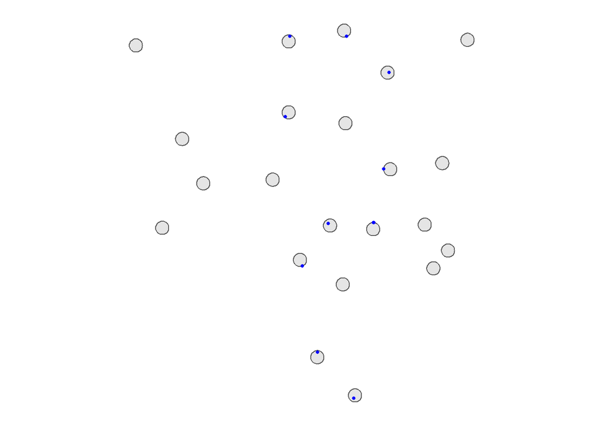

```r
schools_libs <- schools[libs_buffer,]

ggplot(libs_buffer) +
  geom_sf() +
  geom_sf(data = schools_libs,
          color = "blue",
          size = 1) +
  theme_map()
```

```r
schools <- schools %>%
  st_join(schools_libs) %>% #spatial join of schools and libs data
  mutate(by_libs = !is.na(Name.y)) #make a column called name.y and if there is a lib in the specified length, put the name, otherwise na -                                       based on this, if NA than say false, if name than true and call this column by_libs

n_schools_libs <- sum(schools$by_libs) #calculate the number of schools in prox to library through sum of schools with TRUE for by_libs

n_schools_libs #give value amount
```

```
## [1] 11
```

Here, I convert the total number of public schools in a 0.5 mile radius of a public library to a percentage of total public schools. in this case 6%.

```r
n_schools<- length(schools$by_libs) # create a variable n_schools that is the length of all rows in the column by_libs

pct_schools_libs <- n_schools_libs / n_schools #create variable called pct_school that is the number of schools in prox lib/total schools

pct_schools_libs #give variable amount
```

```
## [1] 0.06285714
```

### Creating the final Map of Schools within 0.5 mile of a Library

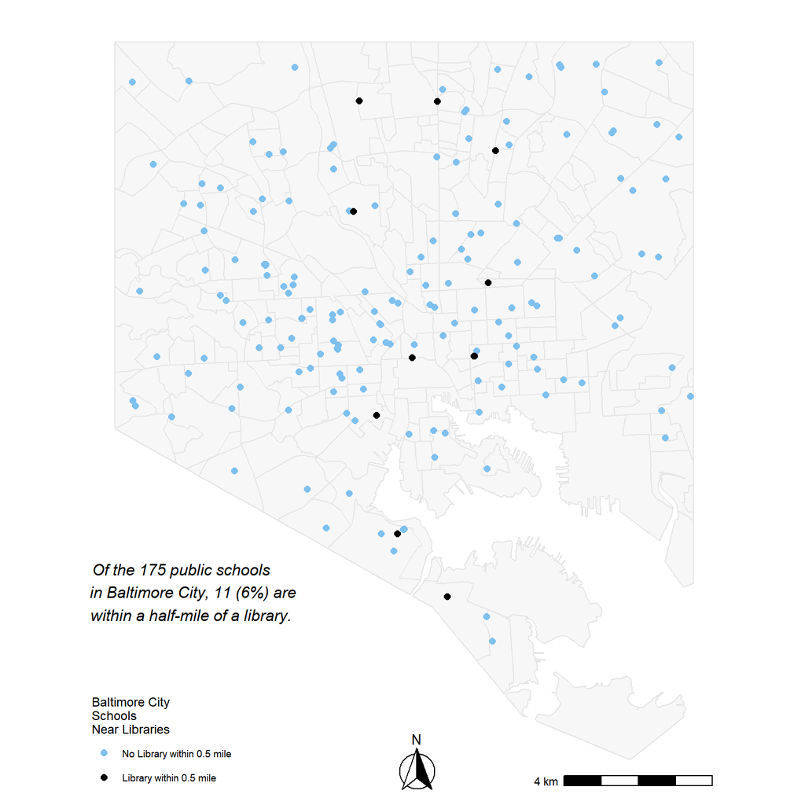

```r
#Need to figure out how to overlay the text over the graph

left_side  <- st_bbox(neighborhoods)$xmin #creating variable that is tied to the spatial xmin of neighborhoods, used to create where text appears later in code
top_side <- st_bbox(neighborhoods)$ymax #creating variable that is tied to the spatial ymin of neighborhoods, used to create where text appears later in code

ggplot(neighborhoods) + #plot neighborhood map
 geom_sf(fill = "grey97", color = "grey90") + #choosing colors of lines (fill) and background (color)
  geom_sf(data = schools, size = 2, #make the data points that appears be based on spatial data of busstop with size 1
          aes(color = by_libs)) + #make the color be based on the variable by_libs - the T or F from above code
  scale_color_manual(values = c("skyblue2", "black"),
          name = "Baltimore City \nSchools\nNear Libraries", #name of the key
          labels = c("No Library within 0.5 mile", #description of the key colors
                     "Library within 0.5 mile"))+
  annotation_scale(location = "br") + #location of scale
  annotation_north_arrow(which_north = "true", #point north
        pad_x = unit(3, "in"), pad_y = unit(0, "in"), #move arrow by in of x and y from point 0 0 being bottom left
        style = north_arrow_fancy_orienteering) + # style of arrow
  annotate(geom = "text", x = left_side,  #put this text at x I specified above
           y = top_side,  #put this text at y I specified above
           label = paste("Of the ", #text to include there
                         prettyNum(n_schools), #insert n_schools number
                         " public schools \nin Baltimore City, ",
                         prettyNum(n_schools_libs), #insert n_schools_libs
                        " (", prettyNum(100*pct_schools_libs, digits = 0), #create percentage based on that number above
                         "%) are\nwithin a half-mile of a library.",
                         sep = ""), fontface = "italic",
           hjust = 0.12, vjust = 10, size = 4) + #size of font and location adjustment
  theme_map() #change theme of map
```

## Density of Public Schools in Baltimore City Neighborhoods

In this section, I look at the number of public schools in each neighborhood in Baltimore and like above, because we have so many neighborhoods in Baltimore that are each of relatively small area, it looks a little odd with many neighborhoods having no schools at all. This code was adapted from the code Carole provided in the tutorial.

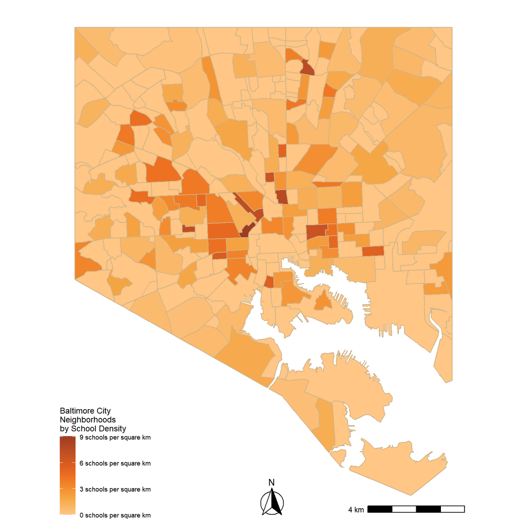

```r
neighborhoods <- neighborhoods %>%
  mutate(area = set_units(st_area(neighborhoods), km^2)) %>% #within neighborhood, make a variable named area that is equal to area of neighborhoods in m2
  mutate(school_dens = as.numeric(num_schools / area)) #make variable school_dens that is a number of number of schools divided by neighborhood variable

ggplot(neighborhoods) +
  geom_sf(color="navajowhite3",
          aes(fill = school_dens)) +
     scale_fill_continuous_tableau(palette = "Orange",name =
                           "Baltimore City\nNeighborhoods\nby School Density",
                       breaks = breaks <- seq(0, 10, by = 3),
                       labels = paste(prettyNum(breaks, big.mark = ","),
                                      "schools per square km")) +
  annotation_scale(location = "br") +
  annotation_north_arrow(which_north = "true",
        pad_x = unit(3, "in"), pad_y = unit(0, "in"),
  style = north_arrow_fancy_orienteering) + # style of arrow
  theme_map()
```

## Map of Baltimore Neighborhoods by Presense of Overlapping Vegetated Area

First, I created two variables, one that looked at the number of neighborhoods that have vegetation overlapping, then I created a binary variable called has_veggie for any neighborhoods with vegetation present. I then summed the number and got 196 neighborhoods. This code was adapted from the code Carole provided in the tutorial.

```r
neighborhoods <- neighborhoods %>%
  mutate(num_veggie = lengths(st_overlaps(neighborhoods, veggie))) %>%
  mutate(has_veggie = num_veggie > 0)

n_veggie_neighborhoods <- sum(neighborhoods$has_veggie)

n_veggie_neighborhoods
```

```
## [1] 196
```

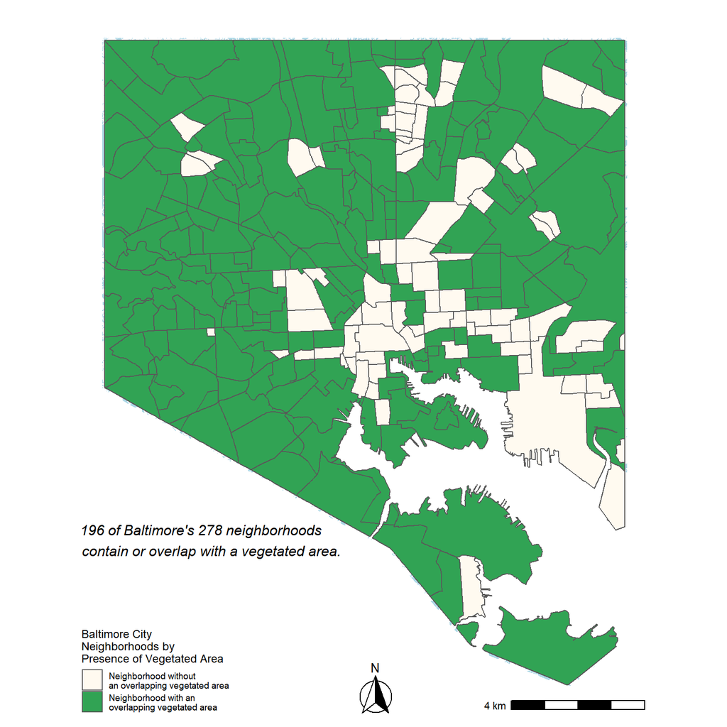

```r
left_side  <- st_bbox(neighborhoods)$xmin
top_side <- st_bbox(neighborhoods)$ymax

ggplot(veggie) +
  geom_sf(fill = "lightblue", color = NA) +
  geom_sf(data = neighborhoods,
          aes(fill = has_veggie)) +
  scale_fill_manual(values = c("floralwhite", col = "#31a354"),
          name = "Baltimore City \nNeighborhoods by \nPresence of Vegetated Area",
          labels = c("Neighborhood without\nan overlapping vegetated area",
                     "Neighborhood with an\noverlapping vegetated area")) +
  annotation_scale(location = "br") +
  annotate(geom = "text", x = left_side,
           y = top_side - 1000,
           label = paste(n_veggie_neighborhoods,
                         "of Baltimore's",
                         length(neighborhoods$Name),
                         "neighborhoods\n contain or overlap with",
                         "a vegetated area."), fontface = "italic",
           hjust = .1, vjust = 16, size = 4) +
  annotation_north_arrow(which_north = "true",
        pad_x = unit(3, "in"), pad_y = unit(0, "in"),
  style = north_arrow_fancy_orienteering) +
  theme(legend.background = element_rect(fill = alpha("white", 0.5),
                                            color="grey")) +
  theme_map()
```

## Chloropleth Map of Free Bus Service Stops in Baltimore Neighborhoods

I found this map really interesting because it shows an disparity people in Baltimore talk about between the “white L” and the “black butterfly.” The free transportation, amenities, bike lanes, grocery stores, ect. are all concentrated in the majority white neighborhoods in the city known as the “white L” (seen below). Whereas, the predominantly black neighborhoods, the “black butterfly”, have a much lower level and concentration of these resources. While I do not have the racial data overlayed in this map, having seen maps of Baltimore’s racial makeup across neighborhoods, the concentration of free bus service stops is nearly 1:1. This code was adapted from the code Carole provided in the tutorial.

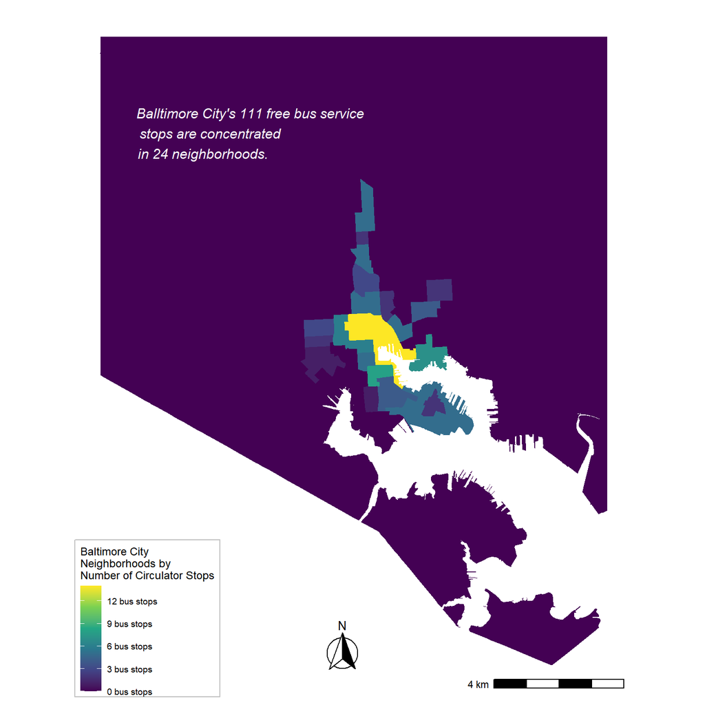

```r
neighborhoods <- neighborhoods %>%
  mutate(num_bus = lengths(st_covers(neighborhoods, busstop)))

left_side  <- st_bbox(neighborhoods)$xmin
top_side <- st_bbox(neighborhoods)$ymax

ggplot(neighborhoods) +
  geom_sf(color=NA,
          aes(fill=num_bus)) +
  scale_fill_viridis_c(option = "viridis", direction = 1, name = "Baltimore City \nNeighborhoods by \nNumber of Circulator Stops",
                       breaks <- seq(0,15, by = 3),
                       labels = paste(prettyNum(breaks, big.mark = ","),
                                      "bus stops")) +
  annotation_scale(location="br") +
  annotation_north_arrow(location = "tr", which_north = "true",
        pad_x = unit(3, "in"), pad_y = unit(7, "in"),
        style = north_arrow_fancy_orienteering)  +
  theme_map() +
    theme(legend.background = element_rect(fill = alpha("white", 0.5),
                                            color="grey"))+
     annotate(geom = "text", x = left_side,
           y = top_side,
           label = paste("Balltimore City's ",
                         length(busstop$by_libs),
                         " free bus service\n    stops are concentrated\n    in 24 neighborhoods.",
                         sep = ""), fontface = "italic",
           hjust = -0.16, vjust = 2.4, size = 4, color = "white")
```

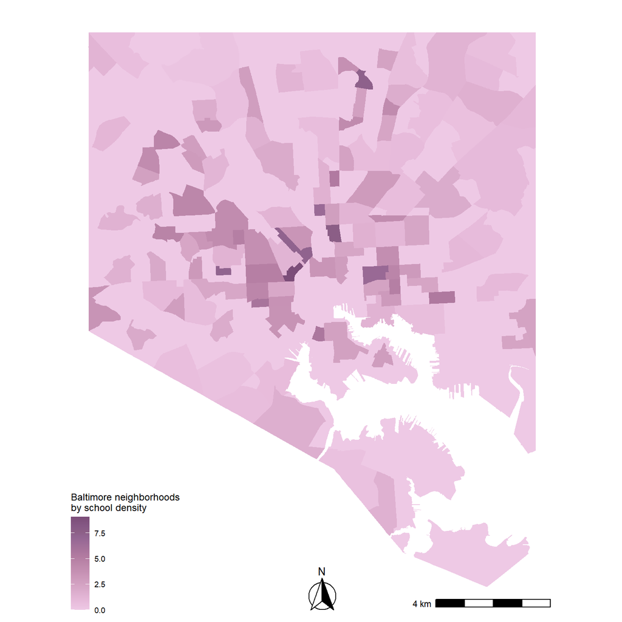

```r
neighborhoods <- neighborhoods %>%
  mutate(area = set_units(st_area(neighborhoods), km^2)) %>% #within neighborhood, make a variable named area that is equal to area of neighborhoods in m2
  mutate(school_dens = as.numeric(num_schools / area)) #make variable school_dens that is a number of number of schools divided by neighborhood variable

ggplot(neighborhoods) +
  geom_sf(color = NA,
          aes(fill = school_dens)) +
     scale_fill_continuous_tableau(palette = "Purple", name = "Baltimore neighborhoods\nby school density") +
  annotation_scale(location = "br") +
  annotation_north_arrow(which_north = "true",
        pad_x = unit(3, "in"), pad_y = unit(0, "in"),
  style = north_arrow_fancy_orienteering) + # style of arrow
  theme_map()
```